# Index

Author

Hannah Shepard-Moore, Gabriel Taylor, Mitchell Zupko, and Anisha Kalra

# Project Goals

DC residents can have vastly different outcomes based upon varying demographics. Oftentimes, the neighborhood in which you live and the community to which you belong can lead to vastly different outcomes in terms of health, education, employment opportunities, etc. This project aims to explore whether demographic differences among student populations in DC public schools can be used to predict educational and/or employment outcomes.

# Literature Review

**Introduction:**

Given the number of variables that can be involved in the notion of socioeconomic demographics, many of the current studies and literature take a different approach on the specific aspects of this broader concept. The research articles included in this literature review uncover common themes across studies conducted on this topic. The review of existing research and the synthesis conducted provides helpful background context for the data analysis conducted on our research question.

**Overview of Findings Across Existing Studies:**

In an article published by the American Psychology Association, the relation between social class and job search outcomes was studied. It was noted that the concept of “self-efficacy” is key when it comes to the job search process (DeOrtentiis, et al. 4). For example, the study stated that the mere act of witnessing successful job outcomes in one’s personal life is likely to lead to stronger confidence in one’s ability to successfully obtain employment opportunities for themselves (DeOrtentiis, et al. 4). This indicates that there may be a correlation between socioeconomic status and employment outcomes for an entire family. The multi-generational impacts of socioeconomic status is something to explore further in subsequent analyses. In the research question for this study, the goal is to understand the effects of socioeconomic status of students and its impact on educational and employment outcomes. The initial findings of the APA article indicate that the effects of the social class that one grows up in also impacts the outcomes of students themselves through qualitative means such as confidence (DeOrtentiis, et al. 4).

Additionally, a study published by the National Library of Medicine shares the impacts of socioeconomic status on psychological factors such as feelings and behavior (Manstead. 1). The article noted that socioeconomic factors and the background one comes from often “reinforce these influences of social class background” (Manstead. 1). This point further reiterates the impact socioeconomic factors have on outcomes related to education and employment, indicating that the social class status of a household one is raised in can play a role throughout an individual’s life.

According to a study conducted by the National Center for Education Statistics (NCES), postsecondary education status was analyzed for ninth-grade students based on socioeconomic status (NCES). This research indicates that students who fell in the lowest fifth quintile of socioeconomic status had fewer individuals (7%) in the “highly-selective, 4-year institution” category, whereas students who fell in the highest fifth quintile of socioeconomic status had 37% of students in the category of “highly-selective, 4-year institution” (NCES). This data suggests that socioeconomic factors do play a significant role in the outcomes of higher education, which can impact future employment outcomes as well.

**Synthesis of Trends and Conclusion**

Overall, many of the current studies conducted on the topic of the impacts of socioeconomic status on education and employment outcomes indicate that socioeconomic status often does have an impact on higher education and employment outcomes. Studies such as the one noted above by the APA suggest that qualitative means such as confidence can vary based on an individual’s socioeconomic status, which can, in turn, play a role in one’s ability to obtain employment successfully (DeOrtentiis, et al. 4). Additionally, the data analysis conducted by the National Center for Education Statistics uncovers existing trends of postsecondary education outcomes as it relates to socioeconomic status of high school students (NCES).

These findings provide meaningful background context as our group conducts data analysis on this topic to explore trends in this arena and answer the research question at hand.

**Work Cited:**

National Center for Education Statistics (NCES). (2022). Young Adult Educational and Employment Outcomes by Family Socioeconomic Status. Condition of Education. U.S. Department of Education, Institute of Education Sciences. Retrieved [date], from https://nces.ed.gov/programs/coe/indicator/tbe.

Manstead ASR. The psychology of social class: How socioeconomic status impacts thought, feelings, and behaviour. Br J Soc Psychol. 2018 Apr;57(2):267-291. doi: 10.1111/bjso.12251. Epub 2018 Feb 28. PMID: 29492984; PMCID: PMC5901394.

DeOrtentiis, P. S., Van Iddekinge, C. H., & Wanberg, C. R. (2021, May 17). Different Starting Lines, Different Finish Times: The Role of Social Class in the Job Search Process. Journal of Applied Psychology. Advance online publication. http://dx.doi.org/10.1037/apl0000915

# Data Wrangling & Cleaning

```r
#packages used
library(tidyverse)
library(tidycensus)
library(sf)
library(sp)
library(tigris)
library(readxl)
library(dplyr)
library(readr)
library(tidyr)
library(dplyr)
library(recipes)
library(ggplot2)
library(janitor)
library(patchwork)
library(tidyclust)
library(tidymodels)
library(tidytext)
library(igraph)
library(ggraph)
library(stringr)
library(textrecipes)
library(stopwords)
library(glmnet) #glm package is incompatible with newer versions of R, according to error messages
library(MachineShop)
library(factoextra)
library(rsample)
library(rpart)
library(tidymodels)
library(parsnip)
```

## Census Data

This data comes from the 2022 American Community Survey, and includes census tract-level data in the District of Columbia. The variables included are income, poverty status, SNAP participation, and insurance coverage. Population level statistics were recorded at the block group level, thus requiring some manipulation to join with other tract level variables.

```r
#load variables
library(tidycensus)

demographics <- get_acs(geography= "tract",
                  state= "DC",
                  county = "District of Columbia",
                  geometry= TRUE,
                  variables= c("income" = "DP03_0062E",
                               "poverty_universe" = "B17001_001",
                               "poverty_status" = "B17001_002",
                               "SNAP_universe" = "B22001_001",
                               "SNAP_status" = "B22001_002",
                               "insurance_universe" = "B27001_001",
                               "insurance_men" = "B27001_002",
                               "insurance_women" = "B27001_030"),
                  year= 2022,
                  progress= FALSE) |>
  select(-NAME,
         -moe) %>%
  pivot_wider(names_from = "variable",
              values_from = "estimate")

#Loading Population separately, as it is at a different geo level
block_stats <- get_acs(geography= "block group",
                  state= "DC",
                  county = "District of Columbia",
                  geometry= TRUE,
                  variables= c("population" = "B01003_001"),
                  year= 2022,
                  progress= FALSE)

#st_write(demographics, "demographics.shp")
##need additional files (e.g. .shx, .proj, etc.)
#demographics <- read_sf("demographics.shp")

#data cleaning

block_stats_clean <- block_stats %>%
  mutate(GEOID = substr(GEOID, 1, nchar(GEOID) - 1)) %>%
  mutate(estimate = as.numeric(estimate)) %>%
  select(-moe) %>%
  st_drop_geometry() |>
  group_by(GEOID) %>%
  pivot_wider(names_from = "variable",
              values_from = "estimate")|>
  select(-NAME) |> #Did not run properly dropping NAME in the earlier step
  group_by(GEOID) %>%
  summarise_all(sum)

demographics <- merge(demographics, block_stats_clean, by = "GEOID", all.x = TRUE)

map_dbl(.x = demographics, .f = ~ sum(is.na(.x)))
```

```
             GEOID   poverty_universe     poverty_status      SNAP_universe
                 0                  0                  0                  0
       SNAP_status insurance_universe      insurance_men    insurance_women
                 0                  0                  0                  0
         DP03_0062         population           geometry
                 5                  0                  0
```

```r
#get rid of census tract with pop=0 or list
demographics_clean <- demographics %>%
  filter(population != 0) %>%
  filter(population != 1983) %>%
  mutate(poverty_status = as.numeric(poverty_status),
         poverty_universe = as.numeric(poverty_universe),
         SNAP_universe = as.numeric(SNAP_universe),
         SNAP_status = as.numeric(SNAP_status),
         insurance_universe = as.numeric(insurance_universe),
         insurance_men = as.numeric(insurance_men),
         insurance_women = as.numeric(insurance_women),
         population = as.numeric(population),
         income = as.numeric(DP03_0062))

#convert totals to percentages
demographics_percap <- demographics_clean %>%
  mutate(poverty_perc = (poverty_status/poverty_universe),
         SNAP_perc = (SNAP_status/SNAP_universe),
         insurance_perc = ((insurance_men + insurance_women)
                           / population))
```

## School Demographics, Test Scores, and Locations

This data comes from two sources, both of which provide data at the school level for elementary, middle, and high schools: District of Columbia Public Schools (proficiency) and DC Open Data (locations). The proficiency data includes both demographic data (racial and socioeconomic) and test data (English and math). The location data gives the latitude and longitude of each school. The dataset includes 73 public Elementary schools, 23 public Middle Schools, and 17 public High Schools in DC. https://dcps.dc.gov/publication/dcps-data-set-parcc https://opendata.dc.gov/datasets/4ac321b2d409438ebd76a6569ad94034/explore

Note: The only racial data that was usable was the black population. All other racial groups had too many “n<10” values, which were used for confidentiality reasons by the school system when the number of students in a racial group was less than 10. This is still a helpful measure of race-based school segregation.

```r
#read in the school data
proficiency <- read_xlsx("proficiency.xlsx")
#replacing "." with NAs
proficiency[proficiency == "."] <- NA
#missing data
map_dbl(.x = proficiency, .f = ~ sum(is.na(.x)))
```

```
    school_name            type       black_pop        poor_pop    english_test
              0               0               4               2               2
          ela_1           ela_2           ela_3           ela_4           ela_5
              2               2               2               2               2
 ela_proficient       math_test          math_1          math_2          math_3
              2               2               2               2               2
         math_4          math_5 math_proficient
              2               2               2
```

```r
#read in the location data
locations <- read_csv("DC_Public_Schools.csv")
locations <- locations %>%
  select(LONGITUDE, LATITUDE, SCHOOL_NAM, GRADES)
locations <- locations %>%
  rename(school_name = SCHOOL_NAM)

# match schools to locations
school_locations <- full_join(proficiency, locations,
                              by= "school_name")

#clean the school locations dataset
#take out NAs in school_locations
school_locations <- school_locations %>%
  filter(!is.na(LONGITUDE))
school_locations <- st_as_sf(school_locations,
                             coords = c("LONGITUDE", "LATITUDE")) %>%
  st_set_crs(value = 4269)
```

## Combined Data

```r
# match locations and demographics
st_crs(school_locations)
```

```
Coordinate Reference System:
  User input: EPSG:4269
  wkt:
GEOGCRS["NAD83",
    DATUM["North American Datum 1983",
        ELLIPSOID["GRS 1980",6378137,298.257222101,
            LENGTHUNIT["metre",1]]],
    PRIMEM["Greenwich",0,
        ANGLEUNIT["degree",0.0174532925199433]],
    CS[ellipsoidal,2],
        AXIS["geodetic latitude (Lat)",north,
            ORDER[1],
            ANGLEUNIT["degree",0.0174532925199433]],
        AXIS["geodetic longitude (Lon)",east,
            ORDER[2],
            ANGLEUNIT["degree",0.0174532925199433]],
    USAGE[
        SCOPE["unknown"],
        AREA["North America - NAD83"],
        BBOX[14.92,167.65,86.46,-47.74]],
    ID["EPSG",4269]]
```

```r
schools <- st_join(demographics_percap, school_locations,
                   join= st_contains)
```

## Data Cleaning

```r
# reducing NAs and changing names
schools <- schools %>%
  filter(!is.na(type)) %>%
  filter(!is.na(school_name))

#turning school type into a factor
schools <- schools %>%
  mutate(type = factor(type, levels = c("es", "ms", "hs"),
                       labels = c("Elementary School", "Middle School", "High School")))

# demographic percents
schools <- schools %>%
  mutate(black_pop = if_else(black_pop == "n < 10", 1, as.numeric(black_pop)))
schools <- schools %>%
  mutate(poor_pop = if_else(poor_pop == "n < 10", 1, as.numeric(poor_pop)))
schools <- schools %>%
  mutate(percent_black = black_pop/english_test)
schools <- schools %>%
  mutate(percent_poor = poor_pop/english_test)

#creation of outcome variables
# continuous: percent proficient in English
schools <- schools %>%
  mutate(percent_ela_proficient = ela_proficient/english_test)
# binary: (1) 50% or more proficient in English
schools <- schools %>%
  mutate(binary_ela_proficient = if_else(percent_ela_proficient >= .50, 1, 0))
# continuous: percent proficient in math
schools <- schools %>%
  mutate(percent_math_proficient = math_proficient/math_test)
# binary: (1) 50% or more proficient in math
schools <- schools %>%
  mutate(binary_math_proficient = if_else(percent_math_proficient >= .50, 1, 0))
```

# Exploratory Data Analysis

There are several variables of interest in our data for the exploratory data analysis, including the school location, the income and insurance use for the census tract, school test scores, and racial makeup of the school population.

### Where are there NAs?

First, we want to check if there are many missing values in the data. No more than 2 missing values exist for any one variable, and most have 0 or 1 missing value.

```r
map_dbl(.x = schools, .f = ~ sum(is.na(.x)))
```

```
                  GEOID        poverty_universe          poverty_status
                      0                       0                       0
          SNAP_universe             SNAP_status      insurance_universe
                      0                       0                       0
          insurance_men         insurance_women               DP03_0062
                      0                       0                       2
             population                  income            poverty_perc
                      0                       2                       0
              SNAP_perc          insurance_perc             school_name
                      0                       0                       0
                   type               black_pop                poor_pop
                      0                       2                       1
           english_test                   ela_1                   ela_2
                      1                       1                       1
                  ela_3                   ela_4                   ela_5
                      1                       1                       1
         ela_proficient               math_test                  math_1
                      1                       1                       1
                 math_2                  math_3                  math_4
                      1                       1                       1
                 math_5         math_proficient                  GRADES
                      1                       1                       0
               geometry           percent_black            percent_poor
                      0                       2                       1
 percent_ela_proficient   binary_ela_proficient percent_math_proficient
                      1                       1                       1
 binary_math_proficient
                      1
```

### What does the distribution of the variables look like?

One can get a general sense of whether a variable is left-skewed, right-skewed, or more centralized by comparing the relative difference in median and mean values. When the median is greater than the mean, the data may be left-skewed, and vice-versa for right-skewed data.

The percentage of school students who are considered poor is skewed to the left, meaning that a greater share of school populations have greater-than-average poverty (in this case, greater than 55%).

The racial makeup of DC public schools is skewed to the left as well, meaning that most schools have a greater-than-average percentage of students who identify as Black or African American (in this case, greater than 69%).

```r
summary(schools)
```

```
    GEOID           poverty_universe poverty_status   SNAP_universe
 Length:113         Min.   :1137     Min.   :  50.0   Min.   : 598
 Class :character   1st Qu.:2518     1st Qu.: 220.0   1st Qu.:1108
 Mode  :character   Median :3169     Median : 426.0   Median :1443
                    Mean   :3308     Mean   : 549.6   Mean   :1490
                    3rd Qu.:3973     3rd Qu.: 723.0   3rd Qu.:1818
                    Max.   :6892     Max.   :2313.0   Max.   :2931

  SNAP_status    insurance_universe insurance_men  insurance_women
 Min.   :  0.0   Min.   :1215       Min.   : 504   Min.   : 646
 1st Qu.: 53.0   1st Qu.:2523       1st Qu.:1217   1st Qu.:1269
 Median :162.0   Median :3215       Median :1570   Median :1630
 Mean   :238.8   Mean   :3352       Mean   :1588   Mean   :1765
 3rd Qu.:340.0   3rd Qu.:4015       3rd Qu.:1922   3rd Qu.:2186
 Max.   :986.0   Max.   :6923       Max.   :3629   Max.   :3504

   DP03_0062        population       income        poverty_perc
 Min.   : 28014   Min.   :1226   Min.   : 28014   Min.   :0.01281
 1st Qu.: 58156   1st Qu.:2538   1st Qu.: 58156   1st Qu.:0.07325
 Median :102600   Median :3215   Median :102600   Median :0.13104
 Mean   :111488   Mean   :3390   Mean   :111488   Mean   :0.16922
 3rd Qu.:166875   3rd Qu.:4083   3rd Qu.:166875   3rd Qu.:0.22730
 Max.   :250001   Max.   :6923   Max.   :250001   Max.   :0.66313
 NA's   :2                       NA's   :2
   SNAP_perc       insurance_perc   school_name                       type
 Min.   :0.00000   Min.   :0.8513   Length:113         Elementary School:73
 1st Qu.:0.05746   1st Qu.:0.9910   Class :character   Middle School    :23
 Median :0.11126   Median :0.9976   Mode  :character   High School      :17
 Mean   :0.16041   Mean   :0.9900
 3rd Qu.:0.24510   3rd Qu.:1.0000
 Max.   :0.53304   Max.   :1.0000

   black_pop        poor_pop       english_test        ela_1
 Min.   :  1.0   Min.   :  1.00   Min.   : 12.00   Min.   :  0.0
 1st Qu.: 19.0   1st Qu.: 18.00   1st Qu.: 32.00   1st Qu.:  6.0
 Median : 27.0   Median : 26.00   Median : 42.00   Median : 10.0
 Mean   : 54.5   Mean   : 41.95   Mean   : 83.27   Mean   : 21.6
 3rd Qu.: 52.5   3rd Qu.: 46.50   3rd Qu.: 82.00   3rd Qu.: 21.0
 Max.   :353.0   Max.   :264.00   Max.   :465.00   Max.   :205.0
 NA's   :2       NA's   :1        NA's   :1        NA's   :1
```

[output cut: 33 more lines]

```
 Min.   :0.0000         Min.   :0.00          Min.   :0.00000
 1st Qu.:0.1494         1st Qu.:0.00          1st Qu.:0.02520
 Median :0.2333         Median :0.00          Median :0.09795
 Mean   :0.3166         Mean   :0.25          Mean   :0.19395
 3rd Qu.:0.4792         3rd Qu.:0.25          3rd Qu.:0.29840
 Max.   :0.9408         Max.   :1.00          Max.   :0.79675
 NA's   :1              NA's   :1             NA's   :1
 binary_math_proficient
 Min.   :0.0000
 1st Qu.:0.0000
 Median :0.0000
 Mean   :0.1339
 3rd Qu.:0.0000
 Max.   :1.0000
 NA's   :1
```

### What does the distribution of student populations look like?

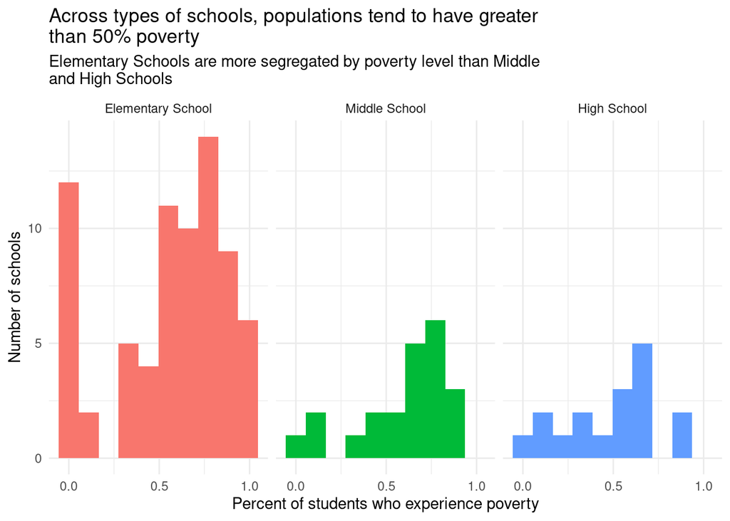

```r
# Percent of students experiencing poverty
schools %>%
  ggplot(mapping= aes(x= percent_poor, fill=type)) +
  geom_histogram(bins= 10,
                 show.legend = FALSE) +
  scale_x_continuous(breaks= c(0, .5, 1)) +
  facet_wrap(~type) +
  labs(title= paste("Across types of schools, populations tend to have greater",
                    "\nthan 50% poverty"),
       subtitle= paste("Elementary Schools are more segregated by poverty",
                       "level than Middle \nand High Schools"),
       x= "Percent of students who experience poverty",
       y= "Number of schools") +
  theme_minimal()
```

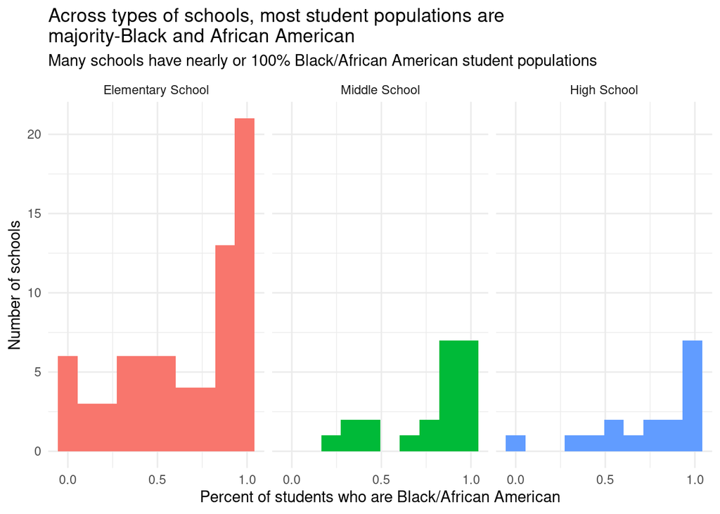

```r
# Percent of students who identify as Black or African American
schools %>%
  ggplot(mapping= aes(x= percent_black, fill=type)) +
  geom_histogram(bins= 10,
                 show.legend = FALSE) +
  scale_x_continuous(breaks= c(0, .5, 1)) +
  facet_wrap(~type) +
  labs(title= paste("Across types of schools, most student populations are",
                    "\nmajority-Black and African American"),
       subtitle= paste("Many schools have nearly or 100% Black/African American",
                       "student populations"),
       x= "Percent of students who are Black/African American",
       y= "Number of schools") +
  theme_minimal()
```